# EBENEZER MARADESA

## Project 3

## Communicate Data Findings

### PART II - EXPLANATORY DATA VISUALIZATION

### DATASET: Diabetes Health Indicators Dataset

- Overview
- Visualizations

# Investigation Overview

The aim of this investigation is to determine how well the occurence of diabetes can be estimated from given characteristics. Specifically, I have focused on BMI as a more reliable variable in the given dataset. Also, I have explored relationships with Age and finally, Sex.

# Dataset Overview

The dataset contains 253680 records of 22 variables, including BMI, Age, Sex, HealthCare Coverage, Alcoholism/Smoking habits, Cholesterol levels, etc, with the target variable being a classification of Diabetes Status into 0 (non-diabetic), 1 (prediabetic) or 2 (diabetic). I have converted most of the variables to categories, and also engineered a new variable, 'BMICategory'.

# Visualizations

## Distribution of BMI

The BMI distribution is unimodal, and it is skewed to the right, suggesting that there are lots of outliers in that direction (that is, extremely high BMI values). The mode comes between 25 and 30, with the majority at about 27.

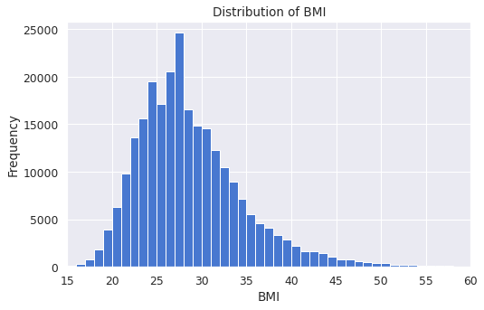

## Frequencies of BMI Categories

It is alarming that the majority of the population covered in the survey is overweight, and the next highest occuring class is that of Obese. People who are of Healthy Weight are less than those who are Overweight and Obese. The number of Extremely Obese persons is also higher than of Underweight persons.

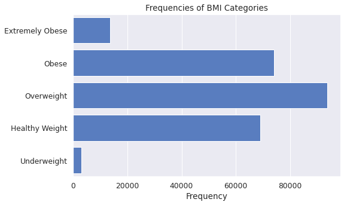

Turning now to the target variable, Diabetes

## Comparing Diabetes with BMI

There is an increased risk of Diabetes with increasing average BMI values. As the BMI class increases, the average BMI associated with the BMI class increases also.

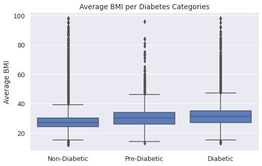

## Which gender is more likely to have Diabetes?

It appears that males are more likely to have Diabetes than females. At the Diabetic point, males have the higher frequency, however more females are prediabetic and non-diabetic.

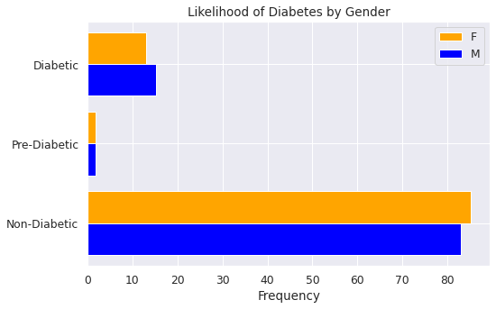

## Diabetes and Age

When comparing diabetes across ages, it can be seen that the risk of diabetes increases with increasing age, and then decreases again at the advanced ages

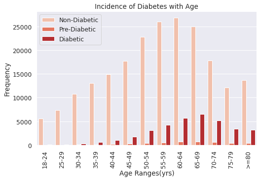

## Diabetes in relation to both BMI and Age

BMI is consistently lower for non-diabetics across all the ages. As BMI increases, chances of Diabetes also increase, and this in turn increases with age such that, at the advanced ages, even lower BMI values have a significant chance of turning out diabetic.

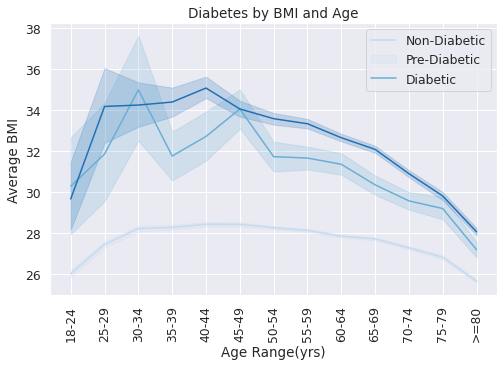

## Diabetes in relation to BMI and Sex

For both genders, diabetes risk increases with average BMI, and the aveage BMI increases according to the BMI class.

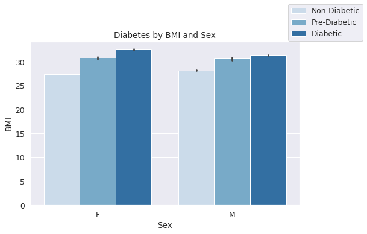

## BMI by Age and Sex

Average BMI for males is higher than for females of the same age group, and this is consistent across all ages. Both lines follow a similar trend, increasing up to the late froties, then declining.

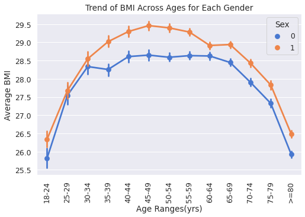

## Putting them all together

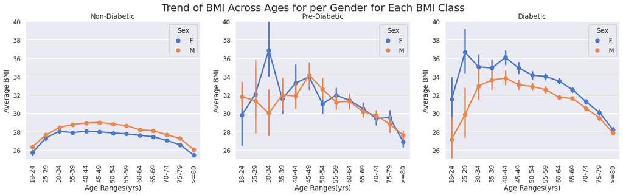